# 4.4_4.5_1

张嘉辰

2020年11月25日

# 新4.4(detecting rare and weak signals)

## 经典算法计算HC值

### 公式一

首先按照高阶鉴定法HC的经典算法计算。

1.步骤

(1)对每个检验计算一个统计量得分，根据统计量得分计算 $p$ 值；

(2)对p值进行排序 $\pi_{(1)}<\pi_{(2)}<\cdots \pi_{(p)}$

(3)计算第 $k$ 个HC值，相当于算了一个二阶 $z$ -得分:
$$H C_{p, k}=\sqrt{p}\left[\frac{k / p-\pi_{(k)}}{\sqrt{\pi_{(k)}\left(1-\pi_{(k)}\right)}}\right]$$
(4)取最大值, 计算相应的 $H C_{p^{*}}=\max _{1 \leqslant k \leqslant p \alpha_{0}}\left\{H C_{p, k}\right\},$ 找到对应的 $\hat{k},$ 前 $k$ 可以认为是真显著的,拒绝所有的 $H_{(i)}, i=1,2, \cdots, k$.

这一公式的名称是Orthodox Higher Criticism (OHC)(见论文*Higher Criticism for Large-Scale Inference, Especially for Rare and Weak Effects*)

2.函数说明

(1)函数功能

函数`HCdetection()`的功能是，输入p值，检测其中稀疏且微弱的信号。

(2)输入的参数

pai，也就是p值，在这里是长度为15的向量。

(3)返回的值

HC_clas，长度为15的向量，是每个p值对应的HC值。

k_hat_clas，是拒绝的检验的个数。

(4)限制条件$\alpha_0$

这里取$\alpha_0=1$

函数如下：

```r
#函数
HCdetection <- function(pai){
#对p值进行排序
  pai <- sort(pai)
#p是p值的个数
  p <- length(pai)
  kk <- c(1:p)/p
#经典算法，计算HC值
  HC_clas <- sqrt(p)*(kk - pai)/sqrt(pai*(1-pai))
#把NaN修正为0
  HC_clas[is.nan(HC_clas)] <- 0

#阈值，注意限制条件
#由于取alpha0=1，所以阈值所在位置是HC的最大值的位置
  L <- which.max(HC_clas)
#k_hat_clas是拒绝的检验的个数
  k_hat_clas <- L
  k_hat_clas

  return(list(HC_clas, k_hat_clas))
}
```

运行函数。

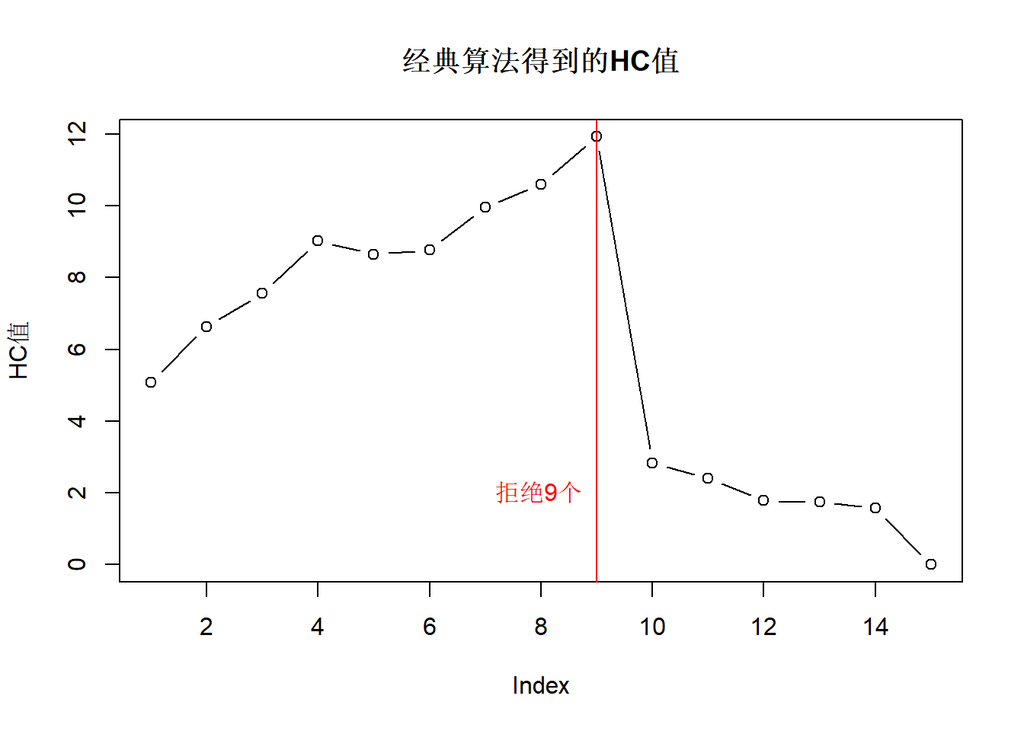

```r
#p值用Π表示
pai <- c(0.0024, 0.0056, 0.0096, 0.0121, 0.0201, 0.0278, 0.0298, 0.0344, 0.0349, 0.3240, 0.4262, 0.5719, 0.6528, 0.7590, 1.0000)
#alpha <- 1， pvalcut <- 0
HC_clas_res <- HCdetection(pai)
HC_clas <- HC_clas_res[[1]]
#拒绝检验的个数
k_hat_clas <- HC_clas_res[[2]]

#画图
plot(HC_clas, type = "b", ylab = "HC值", main = "经典算法得到的HC值")
#用红线标出阈值所在位置
abline(v = k_hat_clas, col = "red")
text(x = k_hat_clas, y = 2, label = c("拒绝9个"), pos = 2, col = "red")
```

得到的HC值与例题中的结果一致。

HC得分先增后降，在9个检验上达到最大。

HC拒绝的检验数量是9。

### 公式二：另一种经典算法的公式

见论文 *Higher criticism thresholding: Optimal feature selection when useful features are rare and weak*

另一种经典算法的公式

(该公式与书上经典算法的公式中，仅分母略有差别)

HC值是

$$H C\left(i ; \pi_{(i)}\right)=\sqrt{N} \frac{i / N-\pi_{(i)}}{\sqrt{i / N(1-i / N)}}$$

$\mathrm{HC}$ 检验统计量是

$$H C^{*}=\max _{1\leq i \leq \alpha_{0} N} H C\left(i ; \pi_{(i)}\right)$$

这里取$\alpha_0=1$

采用这一公式计算得到的HC值如下。

```r
pai <- c(0.0024, 0.0056, 0.0096, 0.0121, 0.0201, 0.0278, 0.0298, 0.0344, 0.0349, 0.3240, 0.4262, 0.5719, 0.6528, 0.7590, 1.0000)
p <- length(pai)
k <- 1:p
HC_clas2 <- sqrt(p)*(k/p - pai)/sqrt((k/p)*(1-k/p))
#把NaN修正为0
HC_clas2[is.nan(HC_clas2)] <- 0
HC_clas2
```

```
##  [1] 0.9978348 1.4553065 1.8435401 2.2295237 2.5734744 2.9424994 3.3914997
##  [8] 3.8733380 4.4675078 2.8152939 2.6899085 2.2085688 2.4366509 2.7067822
## [15] 0.0000000
```

```r
#由于alpha0=1，所以阈值是HC的最大值处
#阈值
thre_clas2 <- max(HC_clas2)
k_hat_clas2 <- which.max(HC_clas2)
k_hat_clas2
```

```
## [1] 9
```

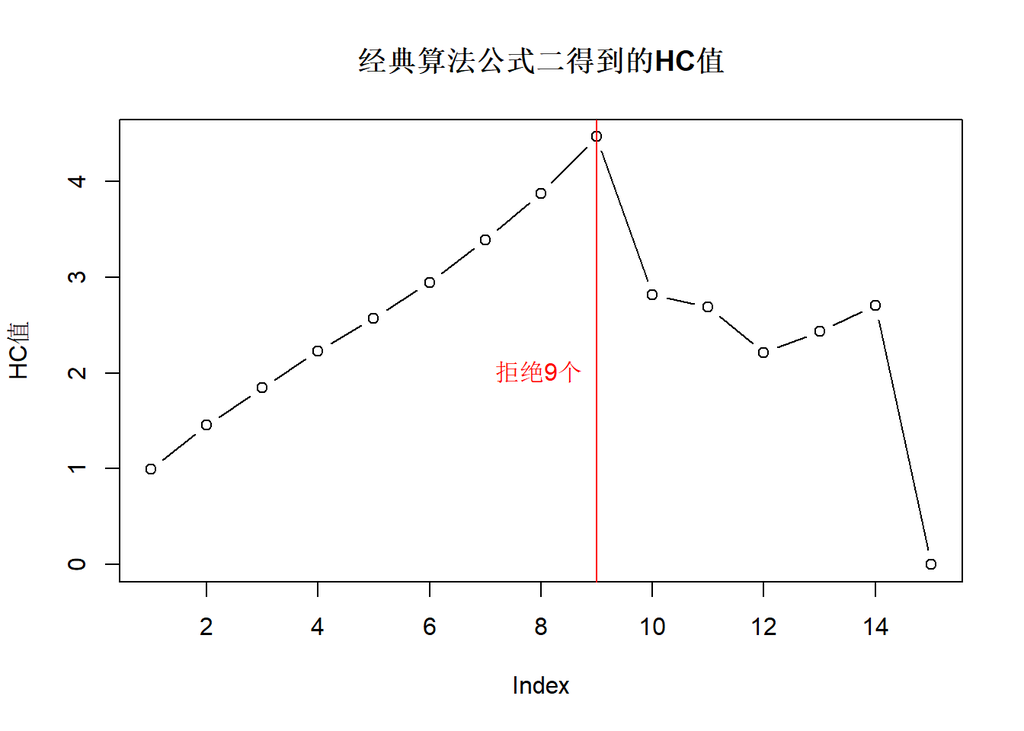

```r
#画图
plot(HC_clas2, type = "b", ylab = "HC值", main = "经典算法公式二得到的HC值")
#用红线标出阈值所在位置
abline(v = k_hat_clas2, col = "red")
text(x = k_hat_clas2, y = 2, label = c("拒绝9个"), pos = 2, col = "red")
```

### 公式二：fdrtool包中的hc.score()和hc.thresh()函数

经典算法的后一种公式与R中`fdrtool`包中的`hc.score()`和`hc.thresh()`函数计算是一致的。

```r
pai <- c(0.00020, 0.00096, 0.00190, 0.00950, 0.02010, 0.02780, 0.02980, 0.03440, 0.03490, 0.32400, 0.42620, 0.57190, 0.65280, 0.75900, 1.0000)
library(fdrtool)
#计算HC值
hc.score(pai)
```

```
##  [1] 1.031993 1.508171 1.918095 2.252295 2.573474 2.942499 3.391500 3.873338
##  [9] 4.467508 2.815294 2.689908 2.208569 2.436651 2.706782 0.000000
```

## IF-PCA方法计算HC值

接下来采用IF-PCA方法计算HC值。

公式为

$$HC_{p, k}=\frac{\sqrt{p}\left(k / p-\pi_{(k)}\right)}{\sqrt{k / p+\max \left\{\sqrt{n}\left(k / p-\pi_{(k)}\right), 0\right\}}}$$
且

$$H C_{p^{*}}=\max _{1 \leqslant k \leqslant p / 2, \pi_{(k)} \leqslant\log p / p}\left\{H C_{p, k}\right\}$$

```r
#使用If-PCA方法计算HC值的函数
#pai为检验的p值，n为每组检验的样本量
PCA_func <- function(pval, n){
  #pval <- pai
  #从小到大排序
  psort <- sort(pval)
  ranking <- rank(pval)
  p <- length(pval)
#用p值算HC
  kk <- c(1:p)/p
  HCsort <- (sqrt(p)*((kk - psort)))/sqrt(kk)
  psort_max_sqrt <- sqrt(n)*(kk - psort)/kk
  psort_max <- rep(0, p)
  for(i in 1:p){
    psort_max[i] <- ifelse(psort_max_sqrt[i]>0,
                           yes = psort_max_sqrt[i],
                           no = 0)}
  HCsort <- HCsort/(sqrt(psort_max + 1))
#阈值，注意限制条件
#pvalcut，为了消除异常值的影响
  pvalcut <- (log(p))/p
  #Ind <- which(psort>pvalcut)[1]
  ratio <- HCsort
  Ind <- which(psort<=pvalcut)[length(which(psort<=pvalcut))]
  #ratio[1:(Ind-1)] = -Inf
  ratio[(Ind+1):length(ratio)] = -Inf
  ratio[(floor(p/2)+1):(length(ratio))]=-Inf
  maxratio <- which(ratio == max(ratio))
  L <- maxratio[length(maxratio)]
#numselect是拒绝的检验的个数
  numselect <- L

#返回HC值，阈值，拒绝的检验的个数
  return(list(HCsort, numselect))
}

#对题中的p值计算HC值
pai <- c(0.00020, 0.00096, 0.00190, 0.00950, 0.02010, 0.02780, 0.02980, 0.03440, 0.03490, 0.32400, 0.42620, 0.57190, 0.65280, 0.75900, 1.0000)
PCA_res <- PCA_func(pai, 30)
#HC值
HC_PCA <- PCA_res[[1]]
HC_PCA
```

```
##  [1] 0.3922403 0.5533608 0.6768182 0.7695264 0.8475092 0.9231019 1.0005774
##  [8] 1.0692350 1.1385527 0.8321452 0.7653544 0.6171096 0.5802030 0.4913630
## [15] 0.0000000
```

```r
#拒绝的检验的个数
k_hat_PCA <- PCA_res[[2]]
k_hat_PCA
```

```
## [1] 7
```

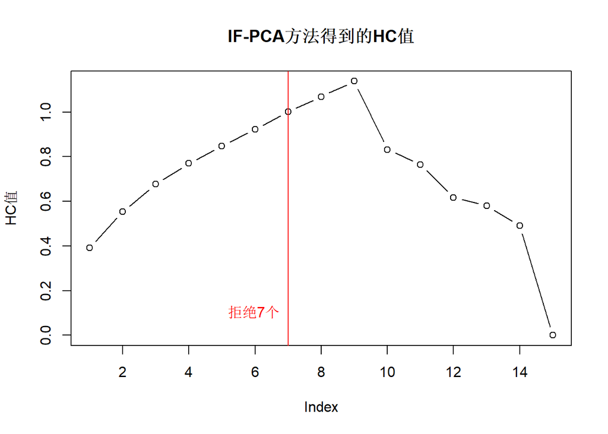

```r
#画图
plot(HC_PCA, type = "b", ylab = "HC值", main = "IF-PCA方法得到的HC值")
#添加标识阈值的红色线
abline(v = k_hat_PCA, col = "red")
text(x = k_hat_PCA, y = 0.1, label = c("拒绝7个"), pos = 2, col = "red")
```

从图中可以看到，用IF-PCA方法计算得到的HC得分先增后降，并且在第9个检验上达到最大。

但是，受条件$1 \leqslant k \leqslant p / 2, \pi_{(k)} \leqslant \log p / p$的限制，选择拒绝的检验数量是7。

与例题中采用经典算法拒绝的检验数量不同。

# 新4.5(clustering & classification)

GitHub上给出的数据是：

EX181.txt，是181个组织样本的数据，每个样本包括12533条基因；

ADCA.txt，是肺癌样本(ADCA,Adenocarcinoma)的训练集。

以下分别进行clustering和classification的计算。

## 1.用IF-PCA方法对每组样本计算HC值，进行基因有效性的检验(clustering)

PCA是因子分析的一种。

这里有两个cluster，分别是MPM和ADCA。

读入EX181.txt数据后，去掉第一列的基因名称后，保存为数据框EX。

将样本数据分为MPM和ADCA两组。MPM组是数据EX的第1至31列，ADCA组是数据EX的32至181列。

对MPM和ADCA这两组样本进行KS检验，得到p值，然后计算HC值，判断无效基因的数量。

### 1.1直接计算KS值

第一个是根据给出的数据EX181，对每一组样本进行KS检验等正态性检验后得到检验的p值，然后运用IF-PCA方法计算HC值，得到可以拒绝的原假设的个数，从而判断无效基因的数量。

```r
#读入数据，为数据框类型
#12533行，182列
#第一列是基因名称，第2-182列是181个组织样本
#每一行是一条基因
EX181 <- read.delim("D:/data/EX181.txt")
#去掉第一列基因名称，保存为EX
#EX有12533行，181列
EX <- EX181[,-1]
#ADCA数据有12533行，16列
ADCA <- read.delim("D:/data/ADCA.txt",sep = " ", header = FALSE)

library(dgof)
EX_MPM <- EX[,1:31]
EX_ADCA <- EX[,32:181]
#EX有12533行

#每条基因都有MPM和ADCA两个病
#检测出p值比较小的，是一条MPM和ADCA两组分布差异比较大的基因，因为要检测的是识别对其中一种疾病有效的
#因为对两种疾病都无效的话，这条基因MPM和ADCA两组分布接近

#对每个基因进行KS检验，得到p值
pai_KS <- apply(EX, 1, function(x) ks.test(x[1:31], x[32:181])$p.value)
#每组检验的样本量
n_gene <- 181

#用IF-PCA方法计算HC值
psort_gene <- sort(pai_KS)
p_gene <- 12533
n_gene <- 181
#kk_gene <- c(1:p_gene)/(1 + p_gene)
kk_gene <- c(1:p_gene)/p_gene
HCsort_gene <- (sqrt(p_gene)*((kk_gene - psort_gene)))/sqrt(kk_gene)
psort_max_sqrt_gene <- sqrt(n_gene)*(kk_gene - psort_gene)/kk_gene
psort_max_gene <- rep(0, p_gene)
for(i in 1:p_gene){
psort_max_gene[i] <- ifelse(psort_max_sqrt_gene[i]>0, yes = psort_max_sqrt_gene[i], no = 0)}
HCsort_gene <- HCsort_gene/(sqrt(psort_max_gene + 1))

#计算阈值时要注意限制条件
pvalcut_gene <- (log(p_gene))/p_gene
#Ind_gene <- which(pai_KS>pvalcut_gene)[1]
ratio_gene <- HCsort_gene
#ratio_gene[1:(Ind_gene-1)] = -Inf
Ind_gene <- which(psort_gene<=pvalcut_gene)[length(which(psort_gene<=pvalcut_gene))]
ratio_gene[(Ind_gene+1):length(ratio_gene)] = -Inf
#ratio[((6267)+1):(length(ratio))]=-Inf
ratio_gene[(6267):(length(ratio_gene))]=-Inf
maxratio_gene <- which(ratio_gene == max(ratio_gene))
L_gene <- maxratio_gene[length(maxratio_gene)]
numselect_gene <- L_gene
numselect_gene
```

```
## [1] 2265
```

### 1.2 参考原matlab代码的clustering

#### 函数 ifpca()

(1)函数功能

函数`ifpca()`对每个样本都得出其标签label（取值为0或1），用于下一步的classification。

(2)输入的参数

Data，这里是12533行，181列的矩阵，p=12533是feature（基因）的个数，n=181是样本的个数；每一列是一个样本。

K，cluster的个数，这里为2，因为有MPM和ADCA两个cluster。

(3)返回的值

label，长度为181的向量，是每个样本的标签label，取值为0或1。

stats.KS，长度为12533的向量，是每个基因的KS值。

stats.HC，长度为12533的向量，是每个基因的HC值。

stats.pval，长度为12533的向量，是每个基因的p值。

stats.ranking，长度为12533的向量，根据p值，基因的秩。

numselect，显著的个数，这里是有效的基因数。

备注：ifpca()函数运行所需时间比较长

```r
ifpca <- function(Data, K){

  #Data <- t(read.csv("D:/data/lungCancer.csv", header = FALSE))

#p=12533，n=181
  p <- nrow(Data)
  n <- ncol(Data)

#标准化
  #对每条基因的181个样本求均值和标准差
  gm <- apply(Data, 1, mean)
  gsd <- apply(Data, 1, sd)
  #Data的每一行是一条基因
  Data <- apply(Data, 2, function(x) (x - gm)/gsd)
#计算KS值
#rep: the number of Kolmogorov-Smirnov statistics to be simulated in the algorithm, defacult 100*p.
#p=12533 n=181
  rep_times <- 100*p
#循环次数原为1253300次，但是实际上到循环100000次已经收敛
#运行时考虑到运行时间可以适当减少循环次数
  rep_times <- 100000
  KSvalue <- rep(0,rep_times)
  kk <- c(0:n)/n

  for(i in 1:rep_times){
    #正态分布的随机数
      x <- rnorm(n)
      z <- (x - mean(x))/sd(x)
      z <- z/sqrt(1 - 1/n)
      pi <- pnorm(z)
      pi <- sort(pi)
#D统计量
      KSvalue[i] = max(max(abs(kk[1:n] - pi)), max(abs(kk[2:(n+1)] - pi)))
}
#KS统计量得分
  KSvalue <- KSvalue*sqrt(n)
#注意删除，释放内存；否则后面计算可能会出错
  rm(x, z, pi, kk)

#重复得到的KSvalue求均值方差，后面用来标准化KS
  KSmean <- mean(KSvalue)
  KSstd <- sd(KSvalue)

#对每个基因算一个KS值
#n=181 p=12533
  kk = (c(0:n))/n
  KS = rep(0, p)
  for(j in 1:p){
    pi <- pnorm(Data[j,]/sqrt(1 - 1/n))
    pi <- sort(pi)
    KS[j] <- (sqrt(n))*(max(max(abs(kk[1:n] - pi)), max(abs(kk[2:(n+1)] - pi))))
    #删除pi
    rm(pi)
}
#每个基因有一个KS值
#对KS值进行标准化(Efron)
  KS <- ((KS - mean(KS))/(sd(KS)))*KSstd + KSmean
#n=181 p=12533
#用KS算p值，每个基因有一个p值
  pval <- rep(0, p)
  for(i in 1:p){
    pval[i] = (sum(KSvalue> KS[i]))/(length(KSvalue))
    }
#将p值从小到大排序
  psort <- sort(pval)
  ranking <- rank(pval)
#用p值算HC
  #kk <- c(1:p)/(1 + p)
  kk <- c(1:p)/p
  HCsort <- (sqrt(p)*((kk - psort)))/sqrt(kk)
  psort_max_sqrt <- sqrt(n)*(kk - psort)/kk
  psort_max <- rep(0, p)
  for(i in 1:p){
    psort_max[i] <- ifelse(psort_max_sqrt[i]>0,
                           yes = psort_max_sqrt[i],
                           no = 0)}
  HCsort <- HCsort/(sqrt(psort_max + 1))
  HC <- rep(0, p)
  HC[ranking] <- HCsort

#阈值，注意限制条件
#pvalcut，为了消除异常值的影响
  pvalcut <- (log(p))/p
  Ind <- which(psort>pvalcut)[1]
  ratio <- HCsort
  ratio[1:(Ind-1)] = -Inf
#这里是因为原来的代码是6258，但是取6257更符合公式
#取6258或6257不影响结果
#ratio[((6267)+1):(length(ratio))]=-Inf
  ratio[(6267):(length(ratio))]=-Inf
  maxratio <- which(ratio == max(ratio))
  L <- maxratio[length(maxratio)]
#numselect是拒绝的检验的个数
  numselect <- L

#每个基因的KS值，HC值，p值，p值的秩
  stats.KS = KS
  stats.HC = HC
  stats.pval = pval
  stats.ranking = ranking
  stats.HCsort = HCsort
#选出的显著的数据
  data_select <- Data[which(pval <= psort[L]), ]

  return(list(numselect, stats.KS, stats.HC, stats.pval, stats.HCsort, stats.ranking))
}
```

#### 运行函数，计算拒绝检验的个数

```r
#运行函数
Data <- t(read.csv("D:/data/lungCancer.csv", header = FALSE))
ifpca_res <- ifpca(Data, 2)
st.num <- ifpca_res[[1]]
st.KS <- ifpca_res[[2]]
st.HC <- ifpca_res[[3]]
st.pval <- ifpca_res[[4]]
st.HCsort <- ifpca_res[[5]]
#选出的个数，251
st.num
```

[output not shown]

#### 画图(p值，KS值，HC值)

下面分别画出p值，KS值，和HC值的图。

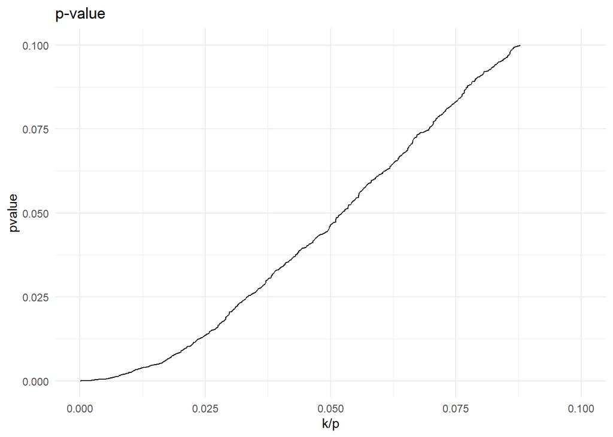

```r
#画图
p <- 12533
library(ggplot2)
kk <- c(1:p)/p
df <- data.frame(kk, pvalue=sort(st.pval), KS=sort(st.KS, decreasing = TRUE), HC=st.HCsort)
#p值
ggplot(df, aes(x = kk, y = pvalue)) + geom_line() + theme_minimal() + scale_x_continuous(limits = c(0, 0.1)) +
  scale_y_continuous(limits = c(0, 0.1)) + labs(x = "k/p", title =  "p-value")
```

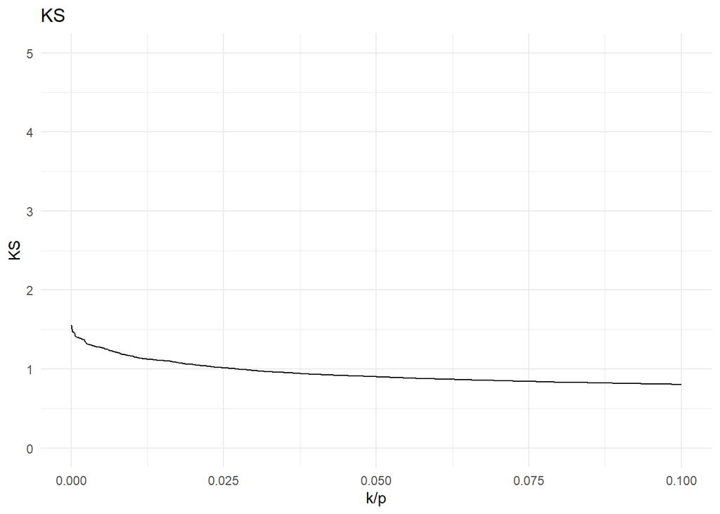

```r
#KS值
ggplot(df, aes(x = kk, y = KS)) + geom_line() + theme_minimal() +
scale_x_continuous(limits = c(0, 0.1)) +
  scale_y_continuous(limits = c(0, 5)) + labs(x = "k/p", title = "KS")
```

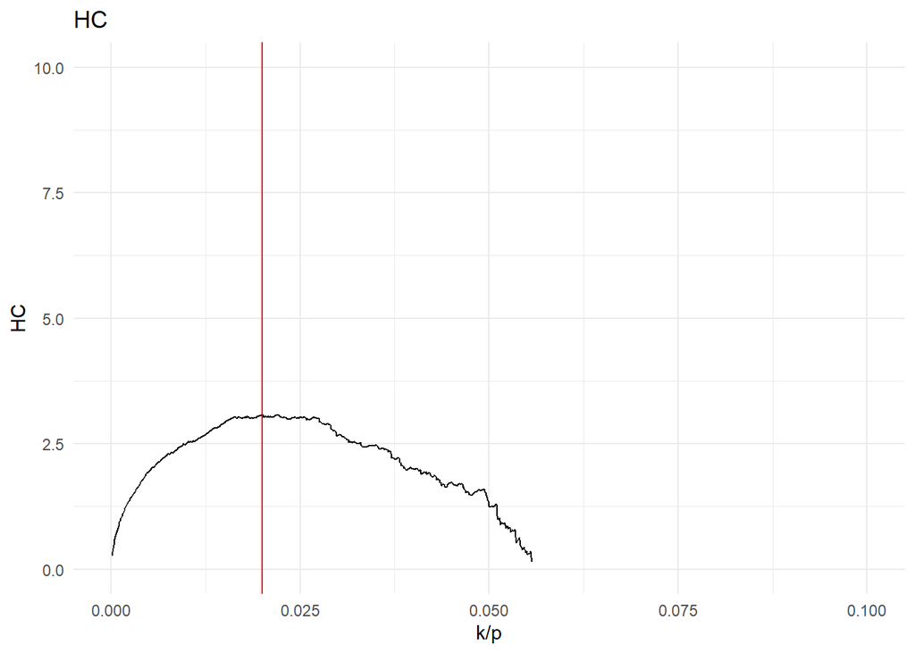

```r
#HC值
ggplot(df, aes(x = kk, y = HC)) + geom_line() + theme_minimal() +
  scale_x_continuous(limits = c(0, 0.1)) +
  scale_y_continuous(limits = c(0, 10)) +
#红线标出显著的位置
  geom_vline(xintercept = 251/12533, col = "red") + labs(x = "k/p", title = "HC")
```

## 2.将样本分为训练集和测试集，对测试集进行预测(classification)(参考原matlab代码)

将所有样本分为训练集和测试集，对测试集中每个样本的标签进行预测。可以求得错误判断的数量，来反映预测的精度。

参考论文2015，Jin做过很多数据集（参考PPT_HC和Github上的论文），主要是leukemia and the lung cancer data，这里只做了lung cancer。

### 1.数据来源和代码参考

这里采用的训练集和测试集的数据来源于lungCancer.mat文件，这里转为了同名的.csv文件。

训练集和测试集的数据均包括标签label信息，标签取值为0或1。

### 2.数据说明

训练集为lungCancertrain.csv，测试集为lungCancer_test.csv。

一共有12533条基因。

训练集和测试集的最后一列均为标签label，值为0或1。

训练的目的是准确预测测试集中的样本的标签。

训练集有32个样本。

测试集有151个样本，但是最后两行的两组样本没有标签信息，所以不可用。

测试集有149个可用的样本。

### 3.计算过程

将通过两个函数`HCclassification()`和`HCclassification_fit()`进行。

#### 函数1 HCclassification()

(1)函数功能

函数`HCclassification()`的功能是，输入训练集的数据，返回权重等信息。

(2)输入的参数

TrainY，在这里是长度为32的向量，是与TrainX对应的标签，值为1或者0。

(3)返回的值

weight，长度为12533的向量，是每条基因的权重。

stats.HC，长度为12533的向量，是每条基因的HC值。

stats.HCT，HC值的阈值。

stats.xbar，长度为12533的向量，是训练集中，标签为1和为0的两组的平均值。

stats.s，长度为12533的向量，是训练集中，标签为1和为0的两组的标准差。

```r
HCclassification <- function(TrainX, TrainY){

  TrainX <- TrainData
  TrainY <- lungCancertrain[, 12534]

  p <- nrow(TrainX)
  p
  n <- ncol(TrainX)
  n
#alpha=0.2是参考了原来的函数HCclassification.m中的默认值
  alpha <- 0.2
#将数据根据标签为0或1分为两组
  Train0 <- TrainX[, which(TrainY == 0)]
  Train1 <- TrainX[, which(TrainY == 1)]
#计算zscore
#两组的均值
  mu1 <- apply(Train0, 1, mean)
#mu1长度是12533，是标签为0的组Train0的每条基因的均值，一条基因一个均值
  mu2 <- apply(Train1, 1, mean)
#mu2长度是12533，是标签为1的组Train1的每条基因的均值，一条基因一个均值

  xbar <- (mu1+mu2)/2
#这里有三种xbar的算法，见HCclassification.m文件

#两组的标准差
#s1和s2的长度均为12533，一条基因得到一个方差
  s1 <- apply(Train0, 1, sd)
  s2 <- apply(Train1, 1, sd)

#n1=16，即标签为0的样本是16个
  n1 <- ncol(Train0)
#n2=16，即标签为1的样本是16个
  n2 <- ncol(Train1)


#计算两组的方差
  s <- (n1-1)*(s1^2) + (n2-1)*(s2^2)
  s <- sqrt(s/(n-2))
  smed <- median(s)
#这里也有三种算法，见HCclassification.m文件
  s <- smed + s
  length(s)

#zscore <- (zscore - mean(zscore))/std(zscore)
  zscore <- (mu1 - mu2)/(s*sqrt(1/n1 + 1/n2))
#zscore长度为12533，计算得到12533个p值
#相当于每条基因分为两组，一组是标签为1，一组是标签为0。对每条基因计算一个zscore，是两组之间的差别

#zscore服从正态分布，计算p值，计算HC
#计算Z-score下，HC值的阈值
  pval  = 2*(1 - pnorm(abs(zscore)))
  kk    = (1:p)/(1 + p)
  psort = sort(pval)
  HC  = (kk - psort)/sqrt(kk - kk^2)
  #alpha The proportion of features with small p-values to calculate HC threshold.
  HC  = HC[1:round(alpha*p)]
  L   = which.max(HC)

#标签为0的组的均值大于标签为1的组的均值的index
  ind1 = which(pval <= psort[L] & zscore >0)
#标签为0的组的均值小于标签为1的组的均值的index
  ind2 = which(pval <= psort[L] & zscore <= 0)

  thr_inx = (pval == psort[L])
  absz    = abs(zscore)
#HCT是最大的HC值对应的p值的zscore的绝对值
  HCT     = max(absz[thr_inx])

#计算权重
  weight = 0*zscore
#求阈值
#这里有三种算法，见HCclassification.m文件
#三种算法在论文Higher criticism thresholding: Optimal feature selection when useful features are rare and weak中有详细说明

#这里用默认的算法("hard")
  weight[ind1] =  abs(zscore[ind1])
  weight[ind2] = -abs(zscore[ind2])

#HC值
  stats.HC = HC
#HC值的阈值
  stats.HCT = HCT
#两组的均值
  stats.xbar = xbar
#两组的标准差
  stats.s = s

return(list(weight, stats.HC ,stats.HCT ,stats.xbar ,stats.s))
}
```

#### 函数2 HCclassification_fit()

(1)函数功能

函数`HCclassification_fit()`的功能是，输入测试集的数据，以及通过训练集得到的权重等信息，对测试集的标签label进行预测。

(2)输入的参数

weight，xbar，s，是函数`HCclassification()`的返回的信息；

Test，测试集的数据，在这里是在这里是12533行，149列的矩阵，每一行是一条基因，每一列是一个样本。

(3)返回的值

label，长度为149的向量，是预测的标签label。

score，长度为149的向量，是对测试集进行标签分类时的得分。

```r
HCclassification_fit <- function(weight, xbar, s, Test){
  p <- nrow(Test)
  m <- ncol(Test)

#对测试集数据进行标准化
#每一列是一个样本，每个样本都有12533条基因。
#对每个样本的每条基因，都减这个基因的xbar，除以这个基因的s
#z是12533行，149列的矩阵
  z = matrix(0, nrow =  p, ncol = m)
  for (j in 1:m){
    z[,j] = (Test[,j] - xbar)/s}

#对测试集的数据的标签进行预测
#weight是长度12533的向量，一个基因有一个权重
  score = t(z)%*%weight
#score是149行，1列
#每一行是一个样本的score，这个score是这个样本包含的12533条基因*每条基因的权重求和得到的

  label = (score <= 0)%*%1
#这是因为前面权重的计算，标签为0的均值更大时权重为正，标签为1的均值更大时权重为负

  return(list(score, label))
}
```

#### 运用以上两个函数，对测试集样本的标签进行预测，输出预测错误的个数

```r
lungCancertrain <- read.csv("D:/data/lungCancertrain.csv", header = FALSE)
lungCancer_test <- read.csv("D:/data/lungCancer_test.csv", header = FALSE)

TrainData = lungCancertrain[, 1:12533]
TrainData = t(TrainData)
Test = lungCancer_test[1:149, 1:12533]
Test = t(Test)
#最后两组样本没有标签为0或1的信息，所以去除最后两行

HC_res <- HCclassification(TrainData, lungCancertrain[, 12534])

#长度为12533的向量，是每条基因的权重
wt <- HC_res[[1]]
#长度为12533的向量，是每条基因的HC值
st.HC <- HC_res[[2]]
#HC值的阈值
st.HCT <- HC_res[[3]]
#长度为12533的向量，是训练集中，标签为1和为0的两组的平均值
st.xbar <- HC_res[[4]]
#长度为12533的向量，是训练集中，标签为1和为0的两组的标准差
st.s <- HC_res[[5]]

#对测试集的标签进行预测
fit_res <- HCclassification_fit(wt, st.xbar, st.s, Test)
score <- fit_res[[1]]
#预测得到的标签
label <- fit_res[[2]]

#对测试集的标签判断错误的个数
#测试集一共有149个样本
#判断正确的个数
sum(label == lungCancer_test[1:149,12534])
```

```
## [1] 148
```

```r
#判断错误的个数
sum(label != lungCancer_test[1:149,12534])
```

```
## [1] 1
```

判断错误的个数仅有一个，说明准确率很高。